# Aula 1: Introdução

Mahayana Godoy

# Análise e Visualização de Dados quantitativos

# Introdução à inferência estatística

# Introdução à estatística: público

Alunos e pesquisadores que precisam lidar com dados quantitativos e testes de hipótese em sua pesquisa e nunca fizeram um curso de estatística e precisam conhecer alguns conceitos como

- P-valor
- Teste de hipóteses
- Correlação linear
- Variáveis dependentes e independentes
- Erro do Tipo I e Erro do Tipo II
- Variáveis de confundimento
- Regressão logística
- ANOVA

# Introdução à estatística: objetivos

O que **NÃO** vamos fazer:

- Aprender a analisar todos os tipos de dados que podem ser obtidos em pesquisas linguísticas

O que **VAMOS** fazer

- Construir autonomia para perguntar ao Google perguntas específicas sobre análises e códigos

# Introdução à estatística: método

Discussão sobre conceitos e métodos a partir da bibliografia indicada

Visualização dos conceitos e implementação dos modelos no R

[figure not shown]

**Download:** https://cran.r-project.org/mirrors.html

[figure not shown]

**Download:** https://www.rstudio.com/products/rstudio/download/

# Introdução à estatística: método

R é um software e uma linguagem de programação. Por que usar?

- Licença livre: você pode usar na sua casa para estudar sem precisar comprar uma licença cara
- Flexibilidade em termos do que você pode fazer com relação a manipulação de dados, plotagem e análise
- Facilidade de compartilhar seu código com pareceristas e colaboradores
- Reprodutibilidade da análise, exigida por alguns periódicos

# Introdução à estatística: método

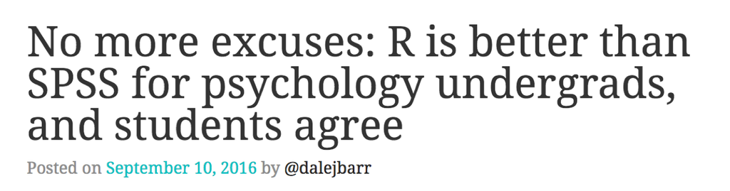

**Fonte**: https://datahowler.wordpress.com/2016/09/10/no-more-excuses-r-is-better-than-spss-for-psychology-undergrads-and-students-agree/

# Introdução à estatística: método

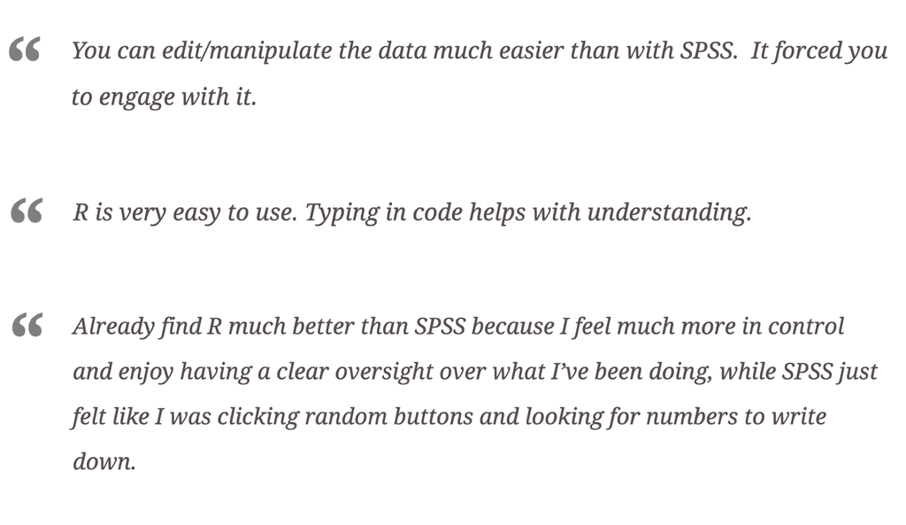

**Fonte**: https://datahowler.wordpress.com/2016/09/10/no-more-excuses-r-is-better-than-spss-for-psychology-undergrads-and-students-agree/

# Introdução à estatística: método

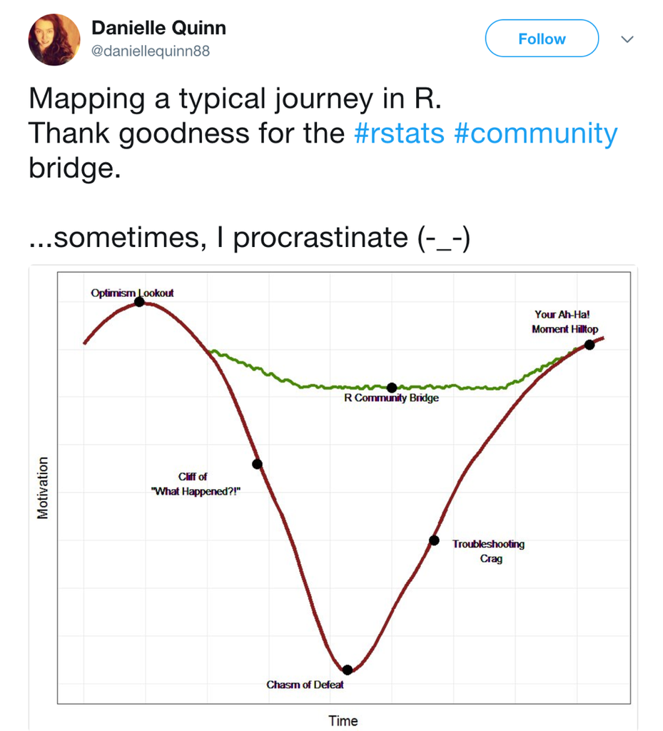

# AULA 1

# Linguística: uma ciência experimental

Conteúdo

- Como testar uma hipótese
- Tipos de variáveis

# Pergunta

Problema: o que define a realização do rótico em posição de coda?

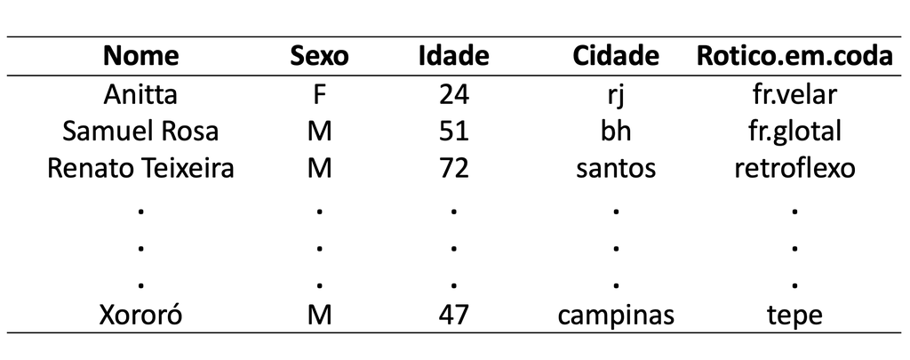

# Variável, dado e observação

**Variável:** característica medida/observada para cada elemento da população/amostra

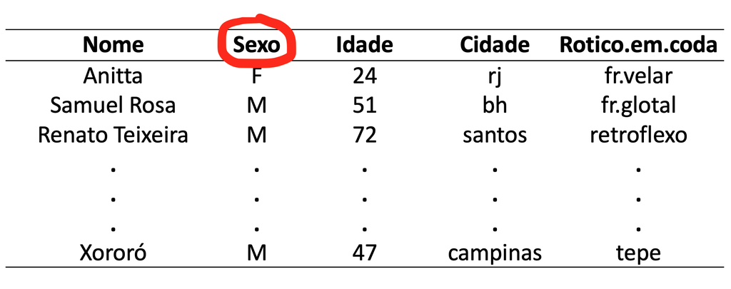

# Variável, dado e observação

**Variável:** característica medida/observada para cada elemento da população/amostra

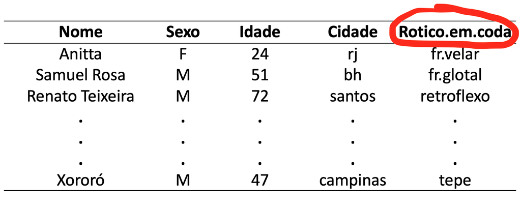

# Variável, dado e observação

**Dado:** valor de uma variável em um elemento da população/amostra

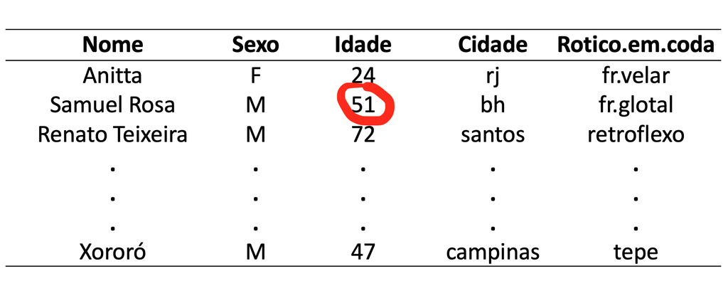

# Variável, dado e observação

**Dado:** valor de uma variável em um elemento da população/amostra

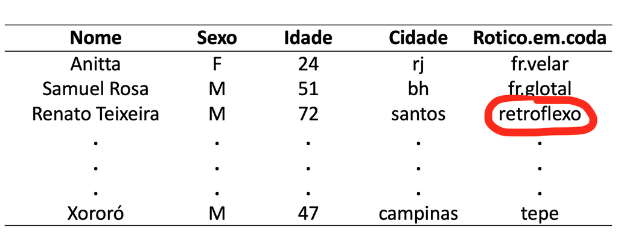

# Variável, dado e observação

**Observação:** valores de todas as variáveis de um elemento em uma população/amostra

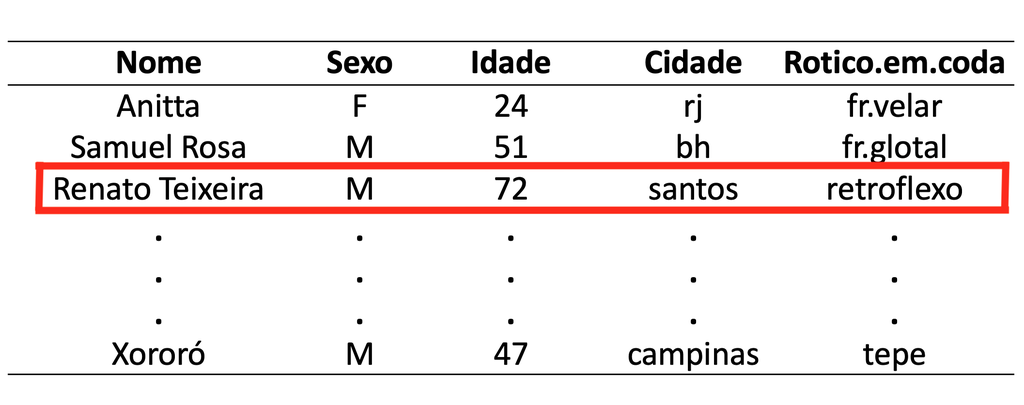

# Relação entre variáveis

**Variável resposta (ou dependendente)**

- Tipo de variável medida ou observada cujo comportamento é estudado pelo pesquisador com relação à sua dependência de outras variáveis

**Variável preditora (ou explicativa, ou independente)**

- Variável que, acredita-se, influencia o comportamento da variável resposta

# Relação entre variáveis

Desejamos saber se a idade e região de nascimento de uma pessoa é capaz de influenciar o tipo de rótico produzido em posição de coda.

**Variável resposta:**

- tipo de rótico

**Variável preditora:**

- idade; região de nascimento

# Relação entre variáveis

Desejamos saber se o tempo que um aluno passa jogando videogame influencia sua fluência em leitura em língua inglesa.

**Variável resposta:**

- fluência

**Variável preditora:**

- tempo de videogame

# Operacionalizando hipóteses

Como medir algo como “fluência” ou “tempo de videogame”?

- É preciso operacionalizar VDs e VIs de uma maneira que possamos controlá-las e medi-las o mais precisamente possível

# Tipos de variáveis

# O que minha variável está quantificando?

**Variáveis qualitativas (ou categóricas):** representam atributos e qualidades

- Nominal: sem ordem natural
- Ordinal: com ordem natural

**Variáveis quantitativas:** são de natureza numérica

- Discreta: resultante de contagens
- Contínua: proveniente de mensuração

# Tipos de variáveis

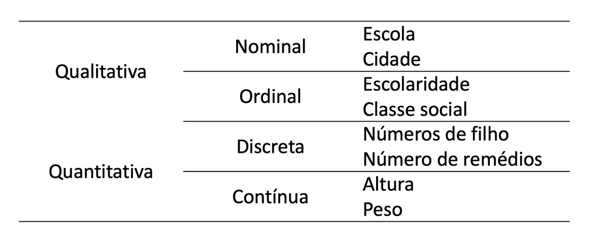

# Tipos de variáveis

- Cor dos olhos
  - qualitativa nominal
- Tipo de esporte
  - qualitativa nominal
- Faixa no judô
  - qualitativa ordinal
- Região do país
  - qualitativa nominal
- Marca de carro
  - qualitativa nominal

# Tipos de variáveis

- Número de dias com chuva no mês
  - quantitativa discreta
- Índice pluviométrico do mês
  - quantitativa contínua
- Idade
  - quantitativa contínua
- Faixa Etária
  - qualitativa ordinal
- Categorias de peso no boxe
  - qualitativa ordinal

# Tipos de variáveis

- Grau de proficiência
  - depende de como você mede…
- Nota de satisfação de 1 (mto insatisfeito) a 7 (mto satisfeito)
  - it’s complicated… (veja: https://stats.stackexchange.com/questions/10/under-what-conditions-should-likert-scales-be-used-as-ordinal-or-interval-data)

# Pense

Quais são as variáveis dependentes e independentes da sua pesquisa de mestrado/doutorado?

Qual a classificação dessas variáveis?